# Reproducible Research: Peer Assessment 1

# Activity data Summaries

## Week 2 Assignment: Reproducible research

## Loading and preprocessing the data

```r
library(dplyr)
activity_dataset <- read.csv(unzip("activity.zip"))
```

## What is mean total number of steps taken per day?

1. Calculate the total number of steps taken per day

```r
total_steps_per_day <- aggregate(steps ~ date, data = activity_dataset, sum, na.rm = TRUE)
```

2. Histogram of the total number of steps taken each day

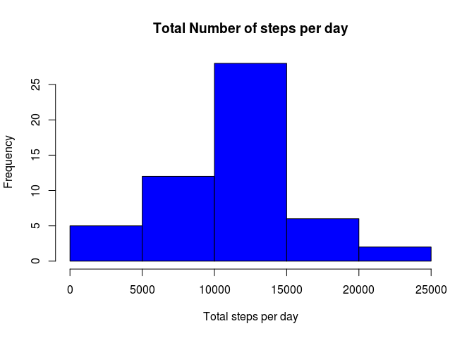

```r
hist(total_steps_per_day$steps, main = "Total Number of steps per day", xlab = "Total steps per day", ylab = "Frequency", col = "blue")
```

3. Calculate and report the mean and median of the total number of steps taken per day

```r
total_mean <- mean(total_steps_per_day$steps)
total_median <- median(total_steps_per_day$steps)
```

## What is the average daily activity pattern?

1. Make a time series plot (i.e. 𝚝𝚢𝚙𝚎 = “𝚕”) of the 5-minute interval (x-axis) and the average number of steps taken, averaged across all days (y-axis)

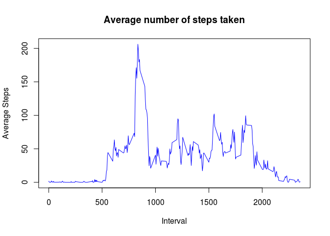

```r
mean_steps_per_interval <- aggregate(steps ~ interval, data = activity_dataset, mean, na.rm = TRUE)

plot(mean_steps_per_interval$interval, mean_steps_per_interval$steps, type = "l", main = "Average number of steps taken", xlab = "Interval", ylab = "Average Steps", col = "blue")
```

```r
max_interval_index <- which.max(mean_steps_per_interval$steps)
max_interval <- mean_steps_per_interval[max_interval_index, ]
```

## Imputing missing values

1. Calculate and report the total number of missing values in the dataset

```r
missing_values_total = nrow(activity_dataset[is.na(activity_dataset$steps), ])
```

The amount of missing step values is: 2304

2. Devise a strategy for filling in all of the missing values in the dataset. The strategy does not need to be sophisticated. For example, you could use the mean/median for that day, or the mean for that 5-minute interval, etc.

We previously computed the 5 minute interval means from the original dataset, so we will use that data to impute the missing values.

3. Create a new dataset that is equal to the original dataset but with the missing data filled in.

```r
imputed_dataset <- activity_dataset
for (i in 1:nrow(activity_dataset)) {
  if (is.na(activity_dataset[i, ]$steps)) {
    imputed_dataset[i, ]$steps <- mean_steps_per_interval[mean_steps_per_interval$interval == activity_dataset$interval[i], ]$steps
  }
}
```

4. Make a histogram of the total number of steps taken each day and Calculate and report the mean and median total number of steps taken per day. Do these values differ from the estimates from the first part of the assignment? What is the impact of imputing missing data on the estimates of the total daily number of steps?

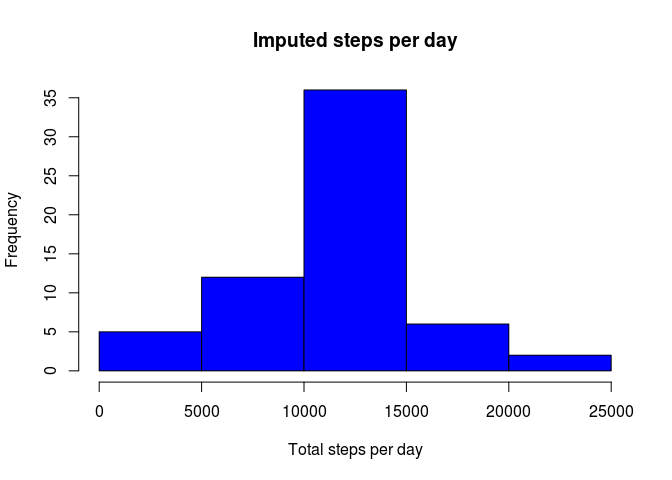

```r
total_steps_per_day <- aggregate(steps ~ date, data = imputed_dataset, sum, na.rm = TRUE)
hist(total_steps_per_day$steps, main = "Imputed steps per day", xlab = "Total steps per day", col = "blue")
```

```r
imputed_mean <- mean(total_steps_per_day$steps)
imputed_median <- median(total_steps_per_day$steps)
```

## Are there differences in activity patterns between weekdays and weekends?

1. Create a new factor variable in the dataset with two levels – “weekday” and “weekend” indicating whether a given date is a weekday or weekend day.

```r
imputed_weekdays <- weekdays(as.Date(imputed_dataset$date))
for (i in 1:length(imputed_weekdays)) {
    if (imputed_weekdays[i] %in% c("Saturday", "Sunday")) {
      imputed_weekdays[i] <- "Weekend"
    } else {
      imputed_weekdays[i] <- "Weekday"
    }
}
imputed_dataset$weekday <- as.factor(imputed_weekdays)
```

2. Make a panel plot containing a time series plot (i.e. 𝚝𝚢𝚙𝚎 = “𝚕”) of the 5-minute interval (x-axis) and the average number of steps taken, averaged across all weekday days or weekend days (y-axis).

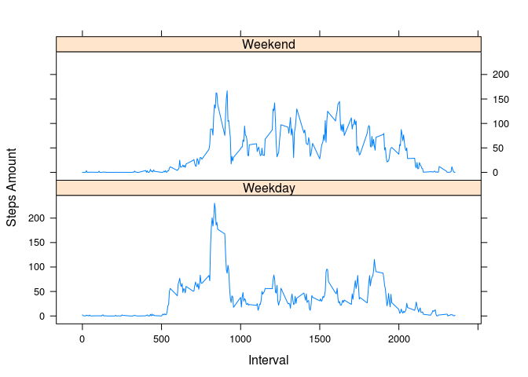

```r
library(lattice)

weekend_dataset <- imputed_dataset[imputed_dataset$weekday == "Weekend", ]
weekday_dataset <- imputed_dataset[imputed_dataset$weekday == "Weekday", ]

total_steps_per_weekend <- aggregate(steps ~ interval, data = weekend_dataset, mean, na.rm = TRUE)
total_steps_per_weekday <- aggregate(steps ~ interval, data = weekday_dataset, mean, na.rm = TRUE)

total_steps_per_weekend$weekday <- "Weekend"
total_steps_per_weekday$weekday <- "Weekday"

totals_combined <- rbind(total_steps_per_weekday, total_steps_per_weekend)

xyplot(steps ~ interval | weekday, totals_combined, type = "l", layout = c(1, 2), xlab = "Interval", ylab = "Steps Amount")
```